# 3 Chapter 5: Image Classification

**`FastAI.jl`**

He we are closely following the `FastAI.jl` tutorials on [data containers](https://fluxml.ai/FastAI.jl/dev/FastAI@dev/doc/docs/data_containers.md.html), [siamese image similarity](https://fluxml.ai/FastAI.jl/dev/FastAI@dev/doc/docs/notebooks/siamese.ipynb.html)

We can load the Pet dataset as follows:

```julia
dir = FastAI.load(datasets()["oxford-iiit-pet"])
```

```
"/Users/FA31DU/.julia/datadeps/fastai-oxford-iiit-pet"
```

```julia
readdir(dir)
```

```
2-element Vector{String}:
 "annotations"
 "images"
```

```julia
img_dir = joinpath(dir, "images")
```

```
"/Users/FA31DU/.julia/datadeps/fastai-oxford-iiit-pet/images"
```

**`FastAI.jl` convention**

Using `FastAI.jl` convention, we can load a single image as follows:

```julia
files = loadfolderdata(img_dir; filterfn=FastVision.isimagefile)
p = getobs(files, 1)
```

```
"/Users/FA31DU/.julia/datadeps/fastai-oxford-iiit-pet/images/Abyssinian_1.jpg"
```

We can see that the file names contain the pet breed.

Using *regular expressions*, we can extract the pet breed from the file name:

```julia
re = r"(.+)_\d+.jpg$"
fname = pathname(p)
label_func(path) = lowercase(match(re, pathname(path))[1])
label_func(fname)
```

```
"abyssinian"
```

Now lets check how many unique pet breeds we have:

```julia
labels = map(label_func, files)
length(unique(labels))
```

```
37
```

We can create a function that loads an image and its class:

```
class = "abyssinian"
```

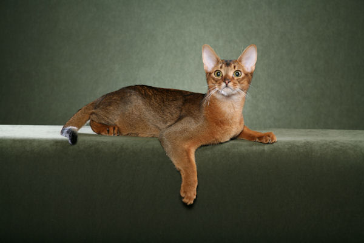

```julia
function loadimageclass(p)
    return (
        @. loadfile(p),                 # broadcasting to make compatible with minibatching
        @. pathname(p) |> label_func
    )
end

image, class = loadimageclass(p)

@show class
image
```

Finally, we can use `mapobs` to lazily load all the images and their classes:

```julia
data = mapobs(loadimageclass, files);
```

```julia
@show numobs(data)
image, label = getobs(data, 1)
```

```
numobs(data) = 7390
```

```
(RGB{N0f8}[RGB{N0f8}(0.118,0.149,0.106) RGB{N0f8}(0.118,0.149,0.106) … RGB{N0f8}(0.161,0.192,0.141) RGB{N0f8}(0.157,0.188,0.137); RGB{N0f8}(0.114,0.145,0.102) RGB{N0f8}(0.114,0.145,0.102) … RGB{N0f8}(0.165,0.196,0.145) RGB{N0f8}(0.157,0.188,0.137); … ; RGB{N0f8}(0.047,0.075,0.043) RGB{N0f8}(0.043,0.…
```

## 3.1 Using the Data Block API

**`FastAI.jl` convention**

Contrary to fast.ai, `FastAI.jl` separates the data loading and container generation from the data augmentation. From the [documentation](https://fluxml.ai/FastAI.jl/dev/FastAI@dev/doc/docs/notebooks/siamese.ipynb.html):

> In FastAI.jl, the preprocessing or “encoding” is implemented through a learning task. Learning tasks contain any configuration and, beside data processing, have extensible functions for visualizations and model building. One advantage of this separation between loading and encoding is that the data container can easily be swapped out as long as it has observations suitable for the learning task (in this case a tuple of two images and a Boolean). It also makes it easy to export models and all the necessary configuration.

First, we follow the standard procedure to split the data into training and validation sets:

```julia
train_data, val_data = splitobs(data; at=0.8, shuffle=true)
```

```
(ObsView(::MLUtils.MappedData{:auto, typeof(loadimageclass), ObsView{MLDatasets.FileDataset{typeof(identity), String}, Vector{Int64}}}, ::Vector{Int64})
 5912 observations, ObsView(::MLUtils.MappedData{:auto, typeof(loadimageclass), ObsView{MLDatasets.FileDataset{typeof(identity), String}, Vector{Int64}}}, ::Vector{Int64})
 1478 observations)
```

Next, we define the data augmentation task separately as a `BlockTask`:

```julia
_resize = 128
blocks = (
    Image{2}(),
    Label{String}(unique(labels)),
)
task = BlockTask(
    blocks,
    (
        ProjectiveTransforms(
            (_resize, _resize),
            sharestate=false,
            buffered=false,
        ),
        ImagePreprocessing(buffered=false),
        OneHot(),
    )
)
describetask(task)
```

**`SupervisedTask` summary**

Learning task for the supervised task with input `Image{2}` and target `Label{String}`. Compatible with `model`s that take in `Bounded{2, FastVision.ImageTensor{2}}` and output `OneHotLabel{String}`.

Encoding a sample (`encodesample(task, context, sample)`) is done through the following encodings:

| Encoding | Name | `blocks.input` | `blocks.target` |
| --- | --- | --- | --- |
|  | `(input, target)` | `Image{2}` | `Label{String}` |
| `ProjectiveTransforms` |  | **`Bounded{2, Image{2}}`** |  |
| `ImagePreprocessing` |  | **`Bounded{2, FastVision.ImageTensor{2}}`** |  |
| `OneHot` | `(x, y)` |  | **`OneHotLabel{String}`** |

We can apply the augmentation to the data as follows:

```julia
batchsize = 3
train_dl, val_dl = taskdataloaders(train_data, val_data, task, batchsize)
```

```
(DataLoader(::FastAI.TaskDataset{ObsView{MLUtils.MappedData{:auto, typeof(loadimageclass), ObsView{MLDatasets.FileDataset{typeof(identity), String}, Vector{Int64}}}, Vector{Int64}}, SupervisedTask{NamedTuple{(:input, :target, :sample, :encodedsample, :x, :y, :ŷ, :pred), Tuple{Image{2}, Label{String}…
```

Let’s quickly verify that the images look as expected:

```julia
showbatch(task, first(train_dl))
```

[figure not shown]

Finally, we can build our model as follows. First, we define the backbone:

```julia
# Get backbone:
_backbone = Metalhead.ResNet(18, pretrain=true).layers[1][1:end-1]
```

```
Chain(
  Chain(
    Conv((7, 7), 3 => 64, pad=3, stride=2, bias=false),  # 9_408 parameters
    BatchNorm(64, relu),                # 128 parameters, plus 128
    MaxPool((3, 3), pad=1, stride=2),
  ),
  Chain(
    Parallel(
      addact(NNlib.relu, ...),
      identity,
      Chain(
        Conv((3, 3), 64 => 64, pad=1, bias=false),  # 36_864 parameters
        BatchNorm(64),                  # 128 parameters, plus 128
        NNlib.relu,
        Conv((3, 3), 64 => 64, pad=1, bias=false),  # 36_864 parameters
        BatchNorm(64),                  # 128 parameters, plus 128
      ),
    ),
    Parallel(
      addact(NNlib.relu, ...),
      identity,
      Chain(
        Conv((3, 3), 64 => 64, pad=1, bias=false),  # 36_864 parameters
        BatchNorm(64),                  # 128 parameters, plus 128
        NNlib.relu,
        Conv((3, 3), 64 => 64, pad=1, bias=false),  # 36_864 parameters
        BatchNorm(64),                  # 128 parameters, plus 128
      ),
    ),
  ),
  Chain(
    Parallel(
      addact(NNlib.relu, ...),
      Chain(
        Conv((1, 1), 64 => 128, stride=2, bias=false),  # 8_192 parameters
        BatchNorm(128),                 # 256 parameters, plus 256
      ),
      Chain(
        Conv((3, 3), 64 => 128, pad=1, stride=2, bias=false),  # 73_728 parameters
        BatchNorm(128),                 # 256 parameters, plus 256
```

[output cut: 31 more lines]

```
    ),
    Parallel(
      addact(NNlib.relu, ...),
      identity,
      Chain(
        Conv((3, 3), 256 => 256, pad=1, bias=false),  # 589_824 parameters
        BatchNorm(256),                 # 512 parameters, plus 512
        NNlib.relu,
        Conv((3, 3), 256 => 256, pad=1, bias=false),  # 589_824 parameters
        BatchNorm(256),                 # 512 parameters, plus 512
      ),
    ),
  ),
)         # Total: 45 trainable arrays, 2_782_784 parameters,
          # plus 30 non-trainable, 4_480 parameters, summarysize 10.649 MiB.
```

Here we have removed the final layer of the ResNet model, because we will instead use a custom head. We could use the `taskmodel` function to build the model with an appropriate head automatically:

```julia
model = taskmodel(task, _backbone)
model.layers[end]
```

```
Chain(
  Parallel(vcat, AdaptiveMeanPool((1, 1)), AdaptiveMaxPool((1, 1))),
  Flux.flatten,
  Chain(
    BatchNorm(512),                     # 1_024 parameters, plus 1_024
    identity,
    Dense(512 => 512, relu; bias=false),  # 262_144 parameters
  ),
  Chain(
    BatchNorm(512),                     # 1_024 parameters, plus 1_024
    identity,
    Dense(512 => 37; bias=false),       # 18_944 parameters
  ),
)         # Total: 6 trainable arrays, 283_136 parameters,
          # plus 4 non-trainable, 2_048 parameters, summarysize 1.089 MiB.
```

Equivalently, we could have obtained an appropriate head as follows,

```julia
h, w, ch, b = Flux.outputsize(_backbone, (_resize, _resize, 3, 1))
_head = Models.visionhead(ch, length(unique(labels)))
```

```
Chain(
  Parallel(vcat, AdaptiveMeanPool((1, 1)), AdaptiveMaxPool((1, 1))),
  Flux.flatten,
  Chain(
    BatchNorm(512),                     # 1_024 parameters, plus 1_024
    identity,
    Dense(512 => 512, relu; bias=false),  # 262_144 parameters
  ),
  Chain(
    BatchNorm(512),                     # 1_024 parameters, plus 1_024
    identity,
    Dense(512 => 37; bias=false),       # 18_944 parameters
  ),
)         # Total: 6 trainable arrays, 283_136 parameters,
          # plus 4 non-trainable, 2_048 parameters, summarysize 1.089 MiB.
```

and then construct our model by chaining the backbone and head:

```julia
Chain(_backbone, _head)
```

```
Chain(
  Chain(
    Chain(
      Conv((7, 7), 3 => 64, pad=3, stride=2, bias=false),  # 9_408 parameters
      BatchNorm(64, relu),              # 128 parameters, plus 128
      MaxPool((3, 3), pad=1, stride=2),
    ),
    Chain(
      Parallel(
        addact(NNlib.relu, ...),
        identity,
        Chain(
          Conv((3, 3), 64 => 64, pad=1, bias=false),  # 36_864 parameters
          BatchNorm(64),                # 128 parameters, plus 128
          NNlib.relu,
          Conv((3, 3), 64 => 64, pad=1, bias=false),  # 36_864 parameters
          BatchNorm(64),                # 128 parameters, plus 128
        ),
      ),
      Parallel(
        addact(NNlib.relu, ...),
        identity,
        Chain(
          Conv((3, 3), 64 => 64, pad=1, bias=false),  # 36_864 parameters
          BatchNorm(64),                # 128 parameters, plus 128
          NNlib.relu,
          Conv((3, 3), 64 => 64, pad=1, bias=false),  # 36_864 parameters
          BatchNorm(64),                # 128 parameters, plus 128
        ),
      ),
    ),
    Chain(
      Parallel(
        addact(NNlib.relu, ...),
        Chain(
          Conv((1, 1), 64 => 128, stride=2, bias=false),  # 8_192 parameters
          BatchNorm(128),               # 256 parameters, plus 256
        ),
        Chain(
          Conv((3, 3), 64 => 128, pad=1, stride=2, bias=false),  # 73_728 parameters
```

[output cut: 47 more lines]

```
    Parallel(vcat, AdaptiveMeanPool((1, 1)), AdaptiveMaxPool((1, 1))),
    Flux.flatten,
    Chain(
      BatchNorm(512),                   # 1_024 parameters, plus 1_024
      identity,
      Dense(512 => 512, relu; bias=false),  # 262_144 parameters
    ),
    Chain(
      BatchNorm(512),                   # 1_024 parameters, plus 1_024
      identity,
      Dense(512 => 37; bias=false),     # 18_944 parameters
    ),
  ),
)         # Total: 51 trainable arrays, 3_065_920 parameters,
          # plus 34 non-trainable, 6_528 parameters, summarysize 11.740 MiB.
```

With the model defined, we can now create a `Learner` object from scratch:

```julia
# Task data loader for new batch size:
batchsize = 64
train_dl, val_dl = taskdataloaders(train_data, val_data, task, batchsize)

# Set up loss function, optimizer, callbacks, and learner:
lossfn = Flux.Losses.logitcrossentropy
optimizer = Flux.Adam()
error_rate(ŷ, y) = mean(onecold(ŷ) .!= onecold(y))
callbacks = [ToGPU(), Metrics(error_rate)]

learner = Learner(
    model, (train_dl, val_dl),
    optimizer, lossfn,
    callbacks...
)
```

```
Learner()
```

**The `FastAI.jl` way**

Most of the manual jobs above can be done automatically using the `tasklearner` function:

```julia
learner = tasklearner(
    task, train_data, val_data;
    backbone=_backbone, callbacks=callbacks,
    lossfn=lossfn, optimizer=optimizer, batchsize=batchsize,
)
```

```
Learner()
```

Note that in this case, we pass on the raw, non-encoded data to the `tasklearner` function. This is because the `tasklearner` function will automatically encode the data using the `task` object.

We will begin by using the learning rate finder to find a good learning rate:

```julia
res = lrfind(learner)
```

[figure not shown]

Figure 3.1: Learning rate finder output.

Below we fine-tune the model for 5 epochs and then save it to disk:

```julia
finetune!(learner, 5, 2e-3)
```

**Freeze epochs**

Note that by default, this will train the model for one epoch with pre-trained weights (our `_backbone`) completely frozen. In other weights, only the parameters of our `_head` will be updated during this epoch, before the second phase of training begins.

Now we will fit the whole training cycle:

```julia
fitonecycle!(learner, 5, 2e-3)
savetaskmodel("artifacts/c5_resnet.jld2", task, learner.model, force=true)
```

```julia
task, model = loadtaskmodel("artifacts/c5_resnet.jld2")

samples = [getobs(data, i) for i in rand(1:numobs(val_data), 3)]
images = [sample[1] for sample in samples]
_labels = [sample[2] for sample in samples]

preds = predictbatch(task, model, images; device = gpu, context=Validation())
```

```
┌ Info: The GPU function is being called but the GPU is not accessible.
└ Defaulting back to the CPU. (No action is required if you want to run on the CPU).
```

```
3-element Vector{String}:
 "bombay"
 "persian"
 "bombay"
```

The accuracy is given by:

```julia
acc = sum(_labels .== preds) / length(preds)
```

```
1.0
```

We can visualize the predictions as follows:

```julia
showsamples(task, collect(zip(images, preds)))
```

[figure not shown]